# Beneath the Surface: A Finding Nemo Character Study

# Intro

Welcome to “Beneath the Surface”! If you’re a fan of the beloved Pixar classic, Finding Nemo, and are interested in analyzing the script using text analysis, you’re in the right place. In this blog, we’ll be taking a deep dive into the words spoken by each of the characters in the movie to uncover their personalities, motivations, and relationships with one another. Using text analysis tools, we’ll be able to examine the language and patterns of speech of each character and draw insights about how they contribute to the overall narrative. Whether you’re a fan of Marlin, Nemo, Crush, or any of the other lovable characters in this underwater adventure, “Beneath the Surface” is the place to be for a closer look at the story of Finding Nemo.

# Wordclouds

## Top Characters

[figure not shown]

## Marlin

[interactive chart not shown]

## Dory

[figure not shown]

## Gill

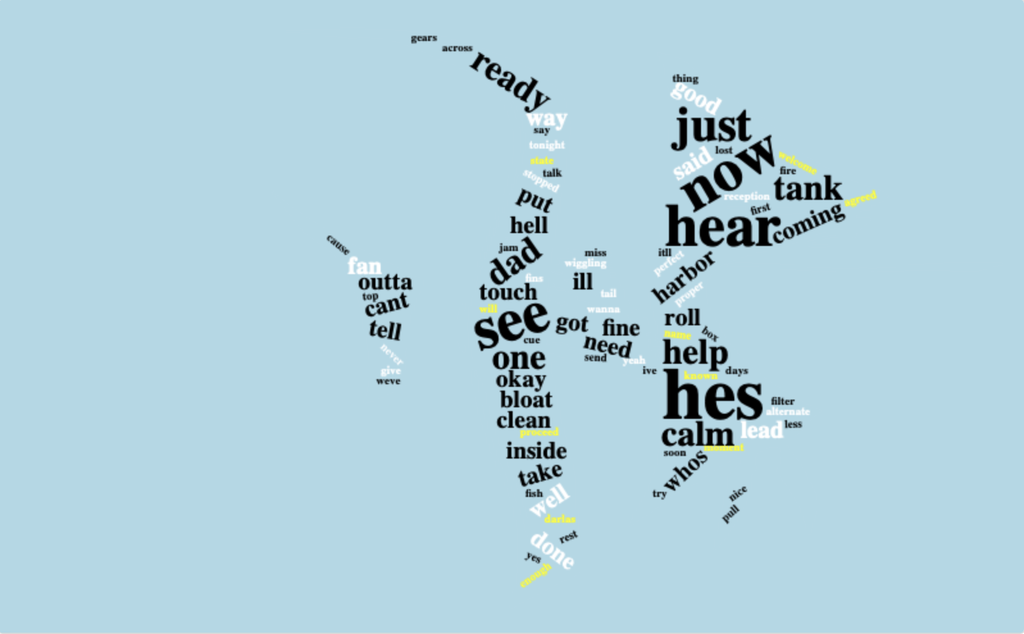

## Peach

[figure not shown]

# Sentiment Analysis

Sentiment Analysis involves analyzing the overall “feel” of a body of text. We wanted to see what the overall sentiments of the main characters were using two common sentiment databases: the AFINN Lexicon and the NRC Lexicon. While these lexicons enable powerful analysis of character’s general sentiments, they are unfortunately not comprehensive and many of the words in Finding Nemo did not appear in either lexicon.

## AFINN Sentiments

The AFINN lexicon assigns each word a number from -5 to 5 according to how “negative” or “positive” a connotation it contains. We averaged these scores across all of the words said by each character, and calculated an average sentiment for each character on a scale of -5 to 5. For simplicity, we count the number of AFINN lexicon words said by each character, and only display the top 10 characters by total AFINN words said

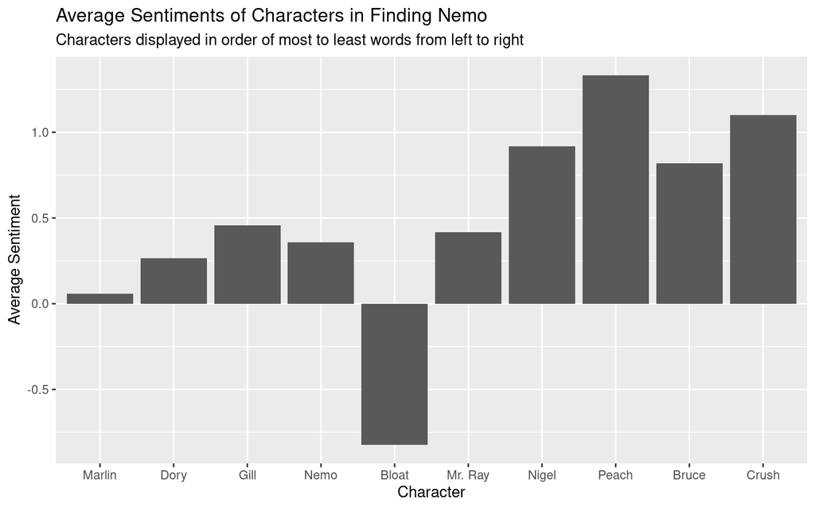

From these results, we can see that most characters are on average fairly positive. This makes sense given Finding Nemo’s status as a PG movie intended for children. Of these characters, Peach and Crush have very positive average sentiments, which tracks with their personalities. Peach, the pink starfish, is a big-sister type character, helping Nemo when he first enters the dentist’s tank. With her positive encouragement and protection, Peach’s dialogue is overall very positive. On the other hand, Crush is a surfer dude type character, and his carefree lifestyle leads to largely positive dialogue. Finally, the one character with a negative overall sentiment is Bloat, the pufferfish. Bloat starts off by scaring Nemo when he first enters the dentist’s office, and throughout the film is generally short-tempered and anxious, leading to an overall negative sentiment.

## NRC Sentiments

In contrast to the AFINN lexicon, the NRC lexicon categorizes words into different sentiment categories such as anticipation, fear, or joy, allowing for one word to exist in multiple categories. In this analysis, we count the number of words in each character’s dialogue associated with each sentiment category, and display the top 5 sentiments in each character’s dialogue. As this analysis is more complex, we only include the top 6 characters by total NRC words said.

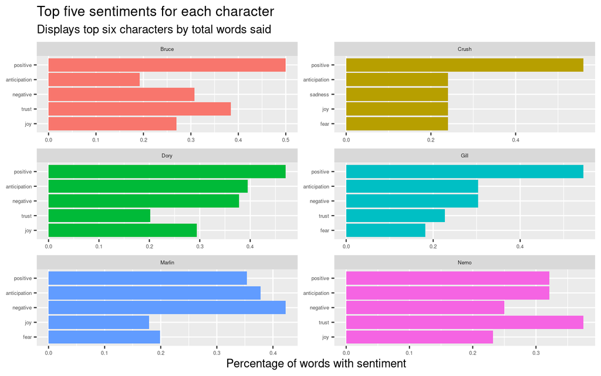

As before, we can see that Crush’s dialogue is mostly positive, with over half of his words belonging to that category. Unfortunately, due to the large number of words that fit into the broad categories of “positive” and “negative,” these sentiment categories figure prominently in each character’s dialogue.

# Network Centrality

## Character Interactions

[figure not shown]

## Character Centrality

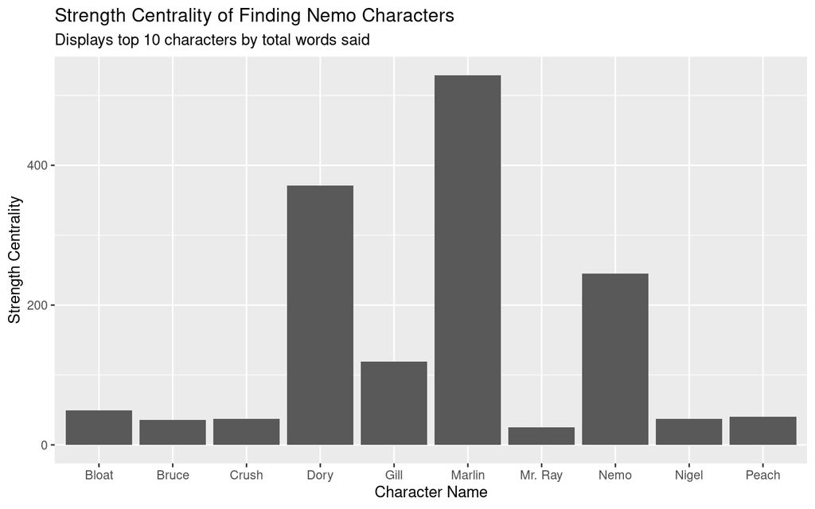